# VA2 - Part. 4

Carlos Maia

2026-06-23

```r
# ============================================================
# PARTE 1 – PREPARAÇÃO DOS DADOS
# ============================================================

library(PNADcIBGE)
library(srvyr)
library(dplyr)
library(summarytools)
library(stargazer)
library(lmtest)
library(ggplot2)
library(readxl)
library(here)
library(forecast)

# 1. Baixando a base do 4º trimestre de 2025
base <- get_pnadc(year = 2025, quarter = 4,
                  vars = c("VD4020", "V2007", "V2009", "VD3005", "VD4001", "UF"))

# 2. Transformação para objeto survey e limpeza inicial
base      <- as_survey(base)
base_isna <- base[!is.na(base$variables$VD4020) & base$variables$VD4020 != 0, ]
base_pea  <- filter(base_isna, VD4001 == "Pessoas na força de trabalho")
base_rj   <- filter(base_pea,  UF     == "Rio de Janeiro")

# 3. Recodificação de Anos de Estudo (0 a 16)
base_final <- mutate(base_rj, anos.de.estudo = recode(VD3005,
  "Sem instrução e menos de 1 ano de estudo" = 0,
  "1 ano de estudo"  = 1,  "2 anos de estudo"  = 2,  "3 anos de estudo"  = 3,
  "4 anos de estudo" = 4,  "5 anos de estudo"  = 5,  "6 anos de estudo"  = 6,
  "7 anos de estudo" = 7,  "8 anos de estudo"  = 8,  "9 anos de estudo"  = 9,
  "10 anos de estudo" = 10, "11 anos de estudo" = 11, "12 anos de estudo" = 12,
  "13 anos de estudo" = 13, "14 anos de estudo" = 14, "15 anos de estudo" = 15,
  "16 anos ou mais de estudo" = 16))

df <- base_final$variables

# 4. Exclusão de outliers de rendimento (Método IQR)
Q1            <- quantile(df$VD4020, 0.25, na.rm = TRUE)
Q3            <- quantile(df$VD4020, 0.75, na.rm = TRUE)
IQR_renda     <- Q3 - Q1
limite_superior <- Q3 + 1.5 * IQR_renda
df <- filter(df, VD4020 <= limite_superior)

# 5. Criação das faixas etária e de estudo
df$faixa_idade <- ifelse(df$V2009 <= 25, "<= 25",
                  ifelse(df$V2009 <= 35, "Entre 26 e 35",
                  ifelse(df$V2009 <= 50, "Entre 36 e 50", "> 50")))
df$faixa_idade <- factor(df$faixa_idade,
                         levels = c("<= 25", "Entre 26 e 35", "Entre 36 e 50", "> 50"))

# ATENÇÃO: o label "> 13" é usado consistentemente em todo o script
df$faixa_estudo <- ifelse(df$anos.de.estudo <= 9, "9 anos ou menos",
                   ifelse(df$anos.de.estudo <= 12, "Entre 10 e 12", "> 13"))
df$faixa_estudo <- factor(df$faixa_estudo,
                          levels = c("9 anos ou menos", "Entre 10 e 12", "> 13"))

# --- Estatísticas descritivas: Gênero ---
cat("=== ESTATÍSTICAS POR GÊNERO ===\n")
```

```
## === ESTATÍSTICAS POR GÊNERO ===
```

```r
cat("Número de Observações:\n"); print(table(df$V2007))
```

```
## Número de Observações:
```

```
##
##  Homem Mulher
##   7362   6441
```

```r
cat("\nRendimento Médio:\n");   print(tapply(df$VD4020, df$V2007, mean))
```

```
##
## Rendimento Médio:
```

```
##    Homem   Mulher
## 2627.530 2272.783
```

```r
cat("\nDesvio Padrão:\n");     print(tapply(df$VD4020, df$V2007, sd))
```

```
##
## Desvio Padrão:
```

```
##    Homem   Mulher
## 1551.035 1513.991
```

```r
# --- Estatísticas descritivas: Faixa Etária ---
cat("\n=== ESTATÍSTICAS POR FAIXA ETÁRIA ===\n")
```

```
##
## === ESTATÍSTICAS POR FAIXA ETÁRIA ===
```

```r
cat("Número de Observações:\n"); print(table(df$faixa_idade))
```

```
## Número de Observações:
```

```
##
##         <= 25 Entre 26 e 35 Entre 36 e 50          > 50
##          1646          2950          4933          4274
```

```r
cat("\nRendimento Médio:\n");    print(tapply(df$VD4020, df$faixa_idade, mean))
```

```
##
## Rendimento Médio:
```

```
##         <= 25 Entre 26 e 35 Entre 36 e 50          > 50
##      1786.225      2516.110      2664.755      2450.863
```

```r
cat("\nDesvio Padrão:\n");      print(tapply(df$VD4020, df$faixa_idade, sd))
```

```
##
## Desvio Padrão:
```

```
##         <= 25 Entre 26 e 35 Entre 36 e 50          > 50
##      1038.469      1506.965      1599.643      1593.296
```

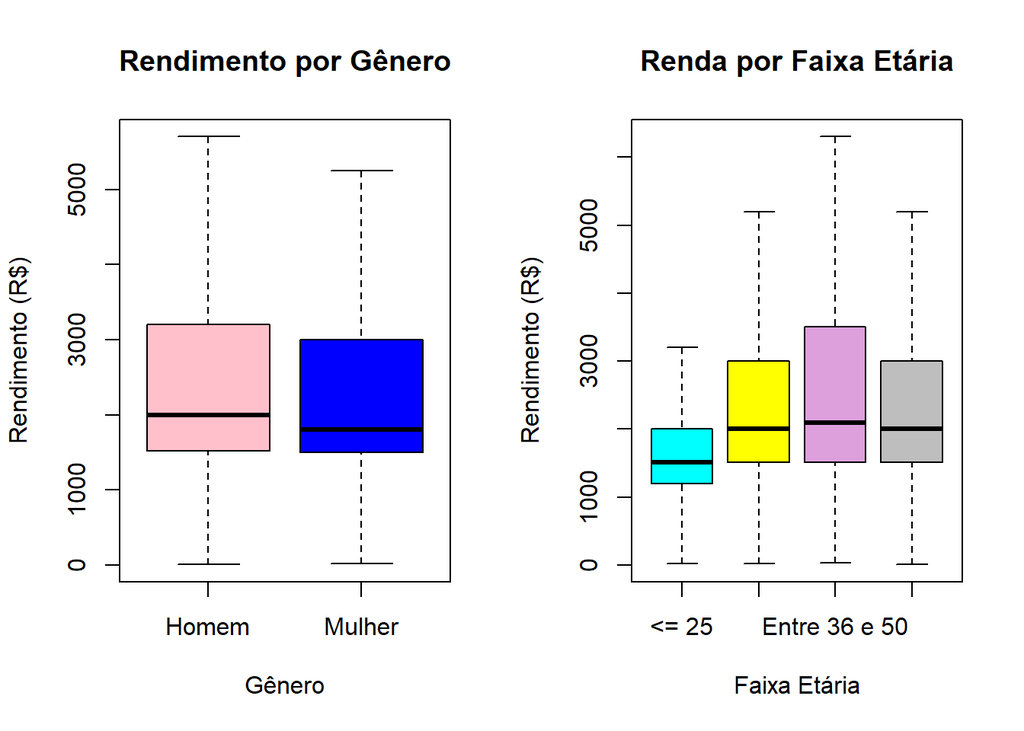

```r
# --- Visualização gráfica ---
par(mfrow = c(1, 2))

boxplot(VD4020 ~ V2007, data = df,
        main = "Rendimento por Gênero",
        ylab = "Rendimento (R$)", xlab = "Gênero",
        col = c("pink", "blue"), outline = FALSE)

boxplot(VD4020 ~ faixa_idade, data = df,
        main = "Renda por Faixa Etária",
        ylab = "Rendimento (R$)", xlab = "Faixa Etária",
        col = c("cyan", "yellow", "plum", "gray"), outline = FALSE)
```

```r
par(mfrow = c(1, 1))
```

**Gênero:** Nota-se uma possível disparidade, onde a mediana e o 3º quartil da população masculina se posicionam acima da feminina, demonstrando desigualdade salarial estrutural na amostra.

**Faixa Etária:** Os rendimentos aumentam das faixas mais jovens para a adulta, atingindo pico entre 36–50 anos. A exclusão de outliers permitiu visualização mais clara do comportamento majoritário.

## Parte 2 – Inferência Cross-Section

### A) Teste Qui-Quadrado (Escolaridade × Rendimento)

```r
# 1. Variável categórica de rendimento (Alta/Baixa em relação à média)
media_renda        <- mean(df$VD4020, na.rm = TRUE)
df$faixa_rendimento <- ifelse(df$VD4020 > media_renda, "Alta", "Baixa")

# 2. Tabela de contingência + Qui-Quadrado
# CORREÇÃO: o nível correto é "> 13", não "Mais de 13"
df$faixa_estudo <- factor(df$faixa_estudo,
                          levels = c("9 anos ou menos", "Entre 10 e 12", "> 13"))

ctable(x = df$faixa_estudo, y = df$faixa_rendimento, chisq = TRUE)
```

```
## Cross-Tabulation, Row Proportions
## faixa_estudo * faixa_rendimento
## Data Frame: df
##
##
## ----------------- ------------------ -------------- -------------- ----------------
##                     faixa_rendimento           Alta          Baixa            Total
##      faixa_estudo
##   9 anos ou menos                       691 (20.2%)   2737 (79.8%)    3428 (100.0%)
##     Entre 10 e 12                      2103 (33.7%)   4135 (66.3%)    6238 (100.0%)
##              > 13                      2667 (64.5%)   1470 (35.5%)    4137 (100.0%)
##             Total                      5461 (39.6%)   8342 (60.4%)   13803 (100.0%)
## ----------------- ------------------ -------------- -------------- ----------------
##
## ----------------------------
##  Chi.squared   df   p.value
## ------------- ---- ---------
##   1702.237     2       0
## ----------------------------
```

**Interpretação (2A):** O teste Qui-Quadrado avalia:

- **H₀:** Faixa de escolaridade e faixa de rendimento são independentes.
- **H₁:** As variáveis são dependentes.

Com p-valor < 0,05, rejeitamos H₀: o nível de escolaridade influencia estatisticamente a probabilidade de pertencer à faixa de renda Alta ou Baixa.

### B) Regressão Linear Simples

```r
# 1. Modelo: Rendimento ~ Anos de Estudo
modelo_simples <- lm(VD4020 ~ anos.de.estudo, data = df)

# 2. Tabela de resultados
stargazer(modelo_simples, type = "text",
          title = "Regressão Linear Simples: Rendimento vs Escolaridade")
```

```
##
## Regressão Linear Simples: Rendimento vs Escolaridade
## ================================================
##                         Dependent variable:
##                     ----------------------------
##                                VD4020
## ------------------------------------------------
## anos.de.estudo               159.169***
##                               (3.342)
##
## Constant                     635.660***
##                               (40.234)
##
## ------------------------------------------------
## Observations                   13,803
## R2                             0.141
## Adjusted R2                    0.141
## Residual Std. Error    1,430.913 (df = 13801)
## F Statistic         2,268.414*** (df = 1; 13801)
## ================================================
## Note:                *p<0.1; **p<0.05; ***p<0.01
```

```r
# 3. Predição para 9 anos de escolaridade
predicao_9_anos <- predict(modelo_simples, newdata = data.frame(anos.de.estudo = 9))
cat("\nRendimento médio esperado para 9 anos de escolaridade: R$",
    round(predicao_9_anos, 2), "\n")
```

```
##
## Rendimento médio esperado para 9 anos de escolaridade: R$ 2068.18
```

**Interpretação (2B):**

- **b1)** O coeficiente de `anos.de.estudo` indica quantos reais, em média, a renda aumenta a cada ano adicional de escolaridade. Com t alto e p < 0,01, o impacto é estatisticamente significativo.
- **b2)** O valor predito acima corresponde à renda esperada de um indivíduo fluminense com 9 anos de estudo.

### C) Diagnóstico dos Resíduos

```r
# Resíduos e valores ajustados
res      <- residuals(modelo_simples)
ajustados <- fitted(modelo_simples)

# --- Testes de hipóteses ---
cat("--- Breusch-Pagan (Homocedasticidade) ---\n")
```

```
## --- Breusch-Pagan (Homocedasticidade) ---
```

```r
print(bptest(modelo_simples))
```

```
##
##  studentized Breusch-Pagan test
##
## data:  modelo_simples
## BP = 359.27, df = 1, p-value < 2.2e-16
```

```r
cat("\n--- Durbin-Watson (Autocorrelação) ---\n")
```

```
##
## --- Durbin-Watson (Autocorrelação) ---
```

```r
print(dwtest(modelo_simples))
```

```
##
##  Durbin-Watson test
##
## data:  modelo_simples
## DW = 1.7299, p-value < 2.2e-16
## alternative hypothesis: true autocorrelation is greater than 0
```

```r
cat("\n--- Shapiro-Wilk (Normalidade) – primeiras 5000 obs. ---\n")
```

```
##
## --- Shapiro-Wilk (Normalidade) – primeiras 5000 obs. ---
```

```r
print(shapiro.test(res[1:5000]))
```

```
##
##  Shapiro-Wilk normality test
##
## data:  res[1:5000]
## W = 0.93798, p-value < 2.2e-16
```

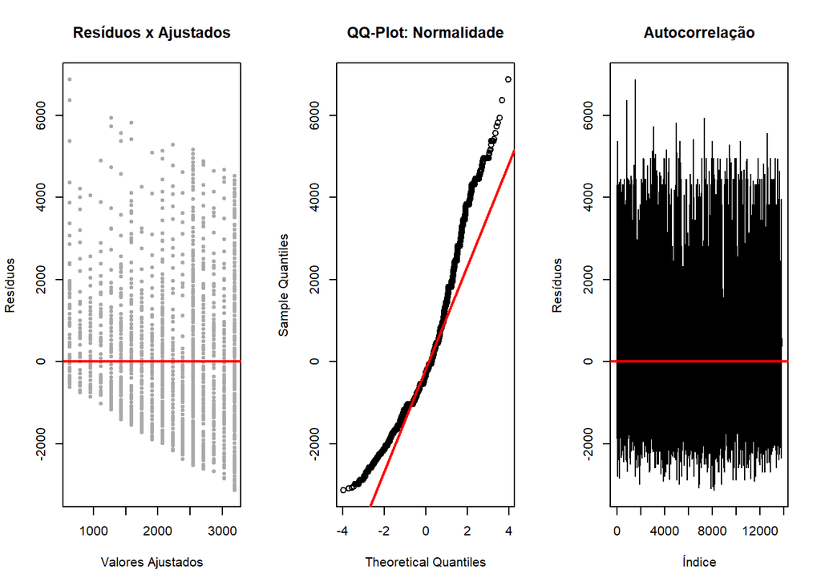

```r
# --- Análise gráfica ---
par(mfrow = c(1, 3))

plot(ajustados, res,
     main = "Resíduos x Ajustados",
     xlab = "Valores Ajustados", ylab = "Resíduos",
     pch = 20, col = "darkgray")
abline(h = 0, col = "red", lwd = 2)

qqnorm(res, main = "QQ-Plot: Normalidade")
qqline(res, col = "red", lwd = 2)

plot(res, type = "l",
     main = "Autocorrelação",
     ylab = "Resíduos", xlab = "Índice")
abline(h = 0, col = "red", lwd = 2)
```

```r
par(mfrow = c(1, 1))
```

**Interpretação (2C):**

- **Homocedasticidade:** Breusch-Pagan rejeita H₀ (p < 0,05) → heterocedasticidade presente, visível no cone do gráfico Resíduos × Ajustados.
- **Normalidade:** Shapiro-Wilk rejeita H₀ (p < 0,05) → não-normalidade confirmada pelo desvio nas caudas do QQ-Plot.
- **Autocorrelação:** Durbin-Watson verifica correlação serial; gráfico de linha permite detectar padrões periódicos nos erros.

## Parte 3 – Modelos Log-Nível e Regressão Múltipla

### 3.1 Modelo Log-Nível e Análise de Resíduos

```r
# Estimando o modelo Log-Nível
modelo_log <- lm(log(VD4020) ~ anos.de.estudo, data = df)

# Imprimindo a tabela do novo modelo
stargazer(modelo_log, type = "text", title = "Regressão Log-Nível (Renda em Log)")
```

```
##
## Regressão Log-Nível (Renda em Log)
## ================================================
##                         Dependent variable:
##                     ----------------------------
##                             log(VD4020)
## ------------------------------------------------
## anos.de.estudo                0.070***
##                               (0.002)
##
## Constant                      6.797***
##                               (0.018)
##
## ------------------------------------------------
## Observations                   13,803
## R2                             0.133
## Adjusted R2                    0.133
## Residual Std. Error      0.651 (df = 13801)
## F Statistic         2,125.852*** (df = 1; 13801)
## ================================================
## Note:                *p<0.1; **p<0.05; ***p<0.01
```

```r
# Resíduos e valores ajustados do modelo log
res_log       <- residuals(modelo_log)
ajustados_log <- fitted(modelo_log)

# --- Testes de hipóteses (modelo log) ---
cat("\n--- Breusch-Pagan (Log-Nível) ---\n")
```

```
##
## --- Breusch-Pagan (Log-Nível) ---
```

```r
print(bptest(modelo_log))
```

```
##
##  studentized Breusch-Pagan test
##
## data:  modelo_log
## BP = 84.671, df = 1, p-value < 2.2e-16
```

```r
cat("\n--- Durbin-Watson (Log-Nível) ---\n")
```

```
##
## --- Durbin-Watson (Log-Nível) ---
```

```r
print(dwtest(modelo_log))
```

```
##
##  Durbin-Watson test
##
## data:  modelo_log
## DW = 1.7506, p-value < 2.2e-16
## alternative hypothesis: true autocorrelation is greater than 0
```

```r
cat("\n--- Shapiro-Wilk (Log-Nível) – primeiras 5000 obs. ---\n")
```

```
##
## --- Shapiro-Wilk (Log-Nível) – primeiras 5000 obs. ---
```

```r
print(shapiro.test(res_log[1:5000]))
```

```
##
##  Shapiro-Wilk normality test
##
## data:  res_log[1:5000]
## W = 0.95622, p-value < 2.2e-16
```

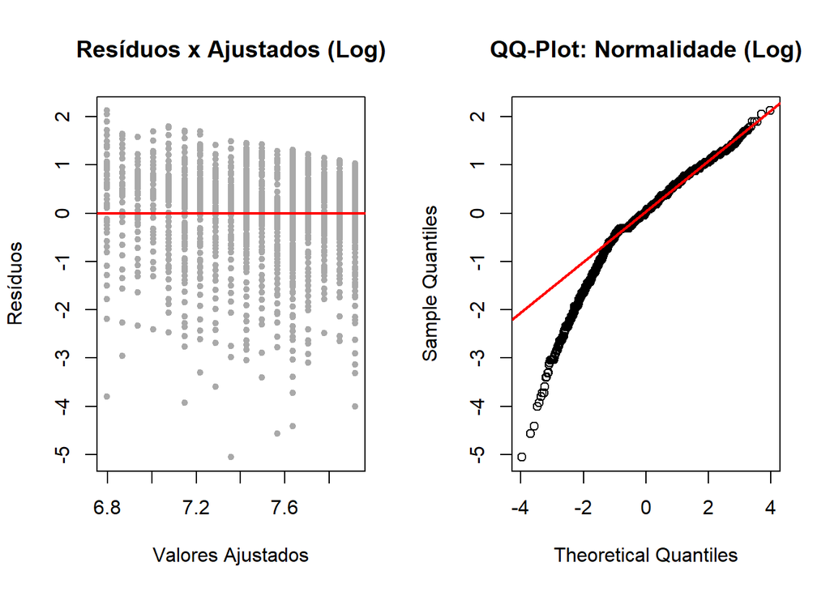

```r
# --- Gráficos diagnósticos do modelo log ---
par(mfrow = c(1, 2))

plot(ajustados_log, res_log,
     main = "Resíduos x Ajustados (Log)",
     xlab = "Valores Ajustados", ylab = "Resíduos",
     pch = 20, col = "darkgray")
abline(h = 0, col = "red", lwd = 2)

qqnorm(res_log, main = "QQ-Plot: Normalidade (Log)")
qqline(res_log, col = "red", lwd = 2)
```

```r
par(mfrow = c(1, 1))
```

**Interpretação (Log-Nível e Resíduos):**

- **Impacto percentual:** No modelo log-nível, o coeficiente de `anos.de.estudo` mede uma variação percentual. Multiplicando-o por 100, obtemos o aumento percentual esperado na renda do indivíduo para cada ano adicional de escolaridade.
- **Melhora nos resíduos:** A transformação logarítmica comprime a escala dos dados. Visualmente, o problema de funil (heterocedasticidade) aparece atenuado no gráfico Resíduos × Ajustados, e o QQ-Plot mostra os pontos mais aderentes à reta normal teórica.

### 3.2 Regressão Múltipla

Estendendo o modelo log-nível para incluir Gênero (`V2007`) e Idade contínua (`V2009`):

```r
# Estimando o modelo múltiplo (usando V2009 contínua)
modelo_mult <- lm(log(VD4020) ~ anos.de.estudo + V2007 + V2009, data = df)

# Comparando os modelos com stargazer
stargazer(modelo_log, modelo_mult, type = "text",
          title = "Comparação: Modelo Simples vs Múltiplo",
          column.labels = c("Log Simples", "Log Múltiplo"))
```

```
##
## Comparação: Modelo Simples vs Múltiplo
## =============================================================================
##                                        Dependent variable:
##                     ---------------------------------------------------------
##                                            log(VD4020)
##                             Log Simples                  Log Múltiplo
##                                 (1)                          (2)
## -----------------------------------------------------------------------------
## anos.de.estudo                0.070***                     0.083***
##                               (0.002)                      (0.002)
##
## V2007Mulher                                               -0.302***
##                                                            (0.011)
##
## V2009                                                      0.007***
##                                                            (0.0004)
##
## Constant                      6.797***                     6.491***
##                               (0.018)                      (0.027)
##
## -----------------------------------------------------------------------------
## Observations                   13,803                       13,803
## R2                             0.133                        0.194
## Adjusted R2                    0.133                        0.194
## Residual Std. Error      0.651 (df = 13801)           0.628 (df = 13799)
## F Statistic         2,125.852*** (df = 1; 13801) 1,108.962*** (df = 3; 13799)
## =============================================================================
## Note:                                             *p<0.1; **p<0.05; ***p<0.01
```

**Interpretação da Regressão Múltipla:** Fez sentido adicionar as variáveis Gênero e Idade — ao incluir variáveis relevantes, a capacidade explicativa do modelo melhora. Observando a tabela `stargazer` acima, nota-se que o R² Ajustado (Adjusted R²) aumentou no modelo múltiplo em relação ao modelo simples, e a variável de idade contínua (`V2009`) apresentou significância estatística.

Essa inferência valida os resultados da estatística descritiva: a regressão múltipla captura esses efeitos mantendo o controle *ceteris paribus* — isto é, mantendo escolaridade e gênero constantes, espera-se que a renda do trabalhador fluminense cresça a cada ano adicional de vida, evidenciado pelo coeficiente positivo da variável idade.

## Parte 4 – Séries Temporais

Nesta parte utilizarei as três séries fornecidas: a concentração mensal de CO₂ em Mauna Loa, o índice mensal de volume de vendas do comércio varejista brasileiro e as vendas semanais de volumes do mangá *One Piece* no Japão.

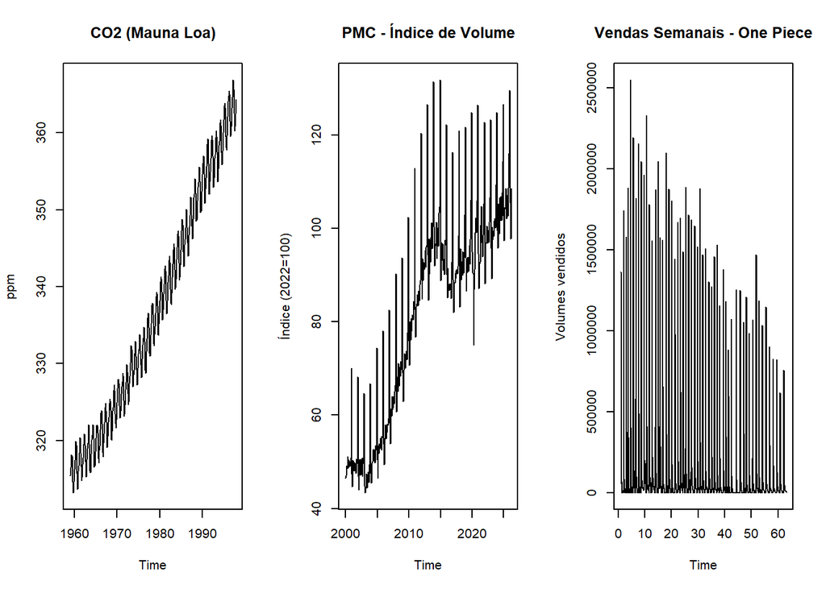

```r
# --- Série 1: CO2 (Mauna Loa) ---
co2_raw <- read.csv(here("serie_co2.csv"), sep = ";", dec = ".")
co2_ts  <- ts(co2_raw$co2_vec, start = c(1959, 1), frequency = 12)

# --- Série 2: PMC - Índice de Volume de Vendas no Varejo (Tabela 8880) ---
pmc_raw <- read_excel(here("Tabela_8880.xlsx"), sheet = "Tabela", col_names = FALSE, skip = 5)
names(pmc_raw) <- c("mes", "indice")
pmc_raw <- pmc_raw[!is.na(pmc_raw$indice), ]  # remove a linha de rodapé ("Fonte: IBGE...")
pmc_ts  <- ts(pmc_raw$indice, start = c(2000, 1), frequency = 12)

# --- Série 3: Venda Semanal de One Piece ---
op_raw <- read_excel(here("Venda_Semanal_One_Piece.xlsx"))
# frequency = 13: o ciclo de lançamento dos volumes no Japão é de
# aproximadamente 13 semanas (trimestral) - não há sazonalidade anual aqui.
# Ver justificativa detalhada na seção a.iii, abaixo.
op_ts  <- ts(op_raw$Vendas, frequency = 13)

par(mfrow = c(1, 3))
plot(co2_ts, main = "CO2 (Mauna Loa)", ylab = "ppm")
plot(pmc_ts, main = "PMC - Índice de Volume", ylab = "Índice (2022=100)")
plot(op_ts,  main = "Vendas Semanais - One Piece", ylab = "Volumes vendidos")
```

```r
par(mfrow = c(1, 1))
```

### a) Decomposição das Três Séries

#### i) CO2 (Mauna Loa)

```r
decomp_co2_add  <- decompose(co2_ts, type = "additive")
decomp_co2_mult <- decompose(co2_ts, type = "multiplicative")

# Verificando se a amplitude sazonal é constante (sugere aditivo) ou
# cresce proporcionalmente ao nível da série (sugere multiplicativo)
ano_co2         <- floor(time(co2_ts))
amplitude_anual <- tapply(as.numeric(co2_ts), ano_co2, function(x) max(x) - min(x))

cat("Amplitude sazonal anual (ppm) - primeiros 5 anos:\n")
```

```
## Amplitude sazonal anual (ppm) - primeiros 5 anos:
```

```r
print(round(head(amplitude_anual, 5), 2))
```

```
## 1959 1960 1961 1962 1963
## 4.95 6.19 5.59 5.58 6.25
```

```r
cat("\nAmplitude sazonal anual (ppm) - últimos 5 anos:\n")
```

```
##
## Amplitude sazonal anual (ppm) - últimos 5 anos:
```

```r
print(round(tail(amplitude_anual, 5), 2))
```

```
## 1993 1994 1995 1996 1997
## 6.56 5.83 6.02 5.94 6.60
```

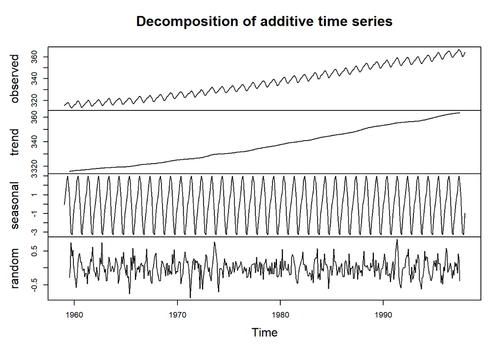

```r
par(mfrow = c(1, 2))
plot(decomp_co2_add)
```

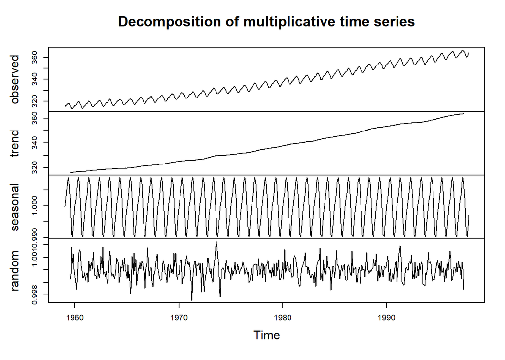

```r
plot(decomp_co2_mult)
```

```r
par(mfrow = c(1, 1))
```

#### ii) PMC – Índice de Volume de Vendas no Varejo

```r
decomp_pmc_add  <- decompose(pmc_ts, type = "additive")
decomp_pmc_mult <- decompose(pmc_ts, type = "multiplicative")

# Comparando o pico de dezembro ("efeito Natal") com a média dos demais
# meses do mesmo ano, em termos absolutos e percentuais
ano_pmc <- floor(time(pmc_ts))
mes_pmc <- cycle(pmc_ts)
pmc_df  <- data.frame(ano = ano_pmc, mes = mes_pmc, valor = as.numeric(pmc_ts))

dezembro     <- pmc_df[pmc_df$mes == 12, c("ano", "valor")]
outros_meses <- aggregate(valor ~ ano, data = pmc_df[pmc_df$mes != 12, ], FUN = mean)
comparacao   <- merge(dezembro, outros_meses, by = "ano", suffixes = c("_dez", "_outros"))
comparacao$diferenca_absoluta   <- comparacao$valor_dez - comparacao$valor_outros
comparacao$diferenca_percentual <- 100 * comparacao$diferenca_absoluta / comparacao$valor_outros

cat("Salto de dezembro ao longo dos anos (absoluto x percentual):\n")
```

```
## Salto de dezembro ao longo dos anos (absoluto x percentual):
```

```r
print(round(comparacao[comparacao$ano %in% c(2000, 2010, 2020, 2025), -1], 1))
```

```
##    valor_dez valor_outros diferenca_absoluta diferenca_percentual
## 1       70.1         49.3               20.8                 42.3
## 11     112.9         79.3               33.6                 42.4
## 21     126.5         95.0               31.5                 33.1
## 26     129.7        105.5               24.1                 22.8
```

```r
cat("\nDesvio-padrão dos resíduos (aditivo, em pontos de índice):",
    round(sd(decomp_pmc_add$random, na.rm = TRUE), 3), "\n")
```

```
##
## Desvio-padrão dos resíduos (aditivo, em pontos de índice): 2.572
```

```r
cat("Desvio-padrão dos resíduos (multiplicativo, em proporção do nível):",
    round(sd(decomp_pmc_mult$random, na.rm = TRUE), 4), "\n")
```

```
## Desvio-padrão dos resíduos (multiplicativo, em proporção do nível): 0.0266
```

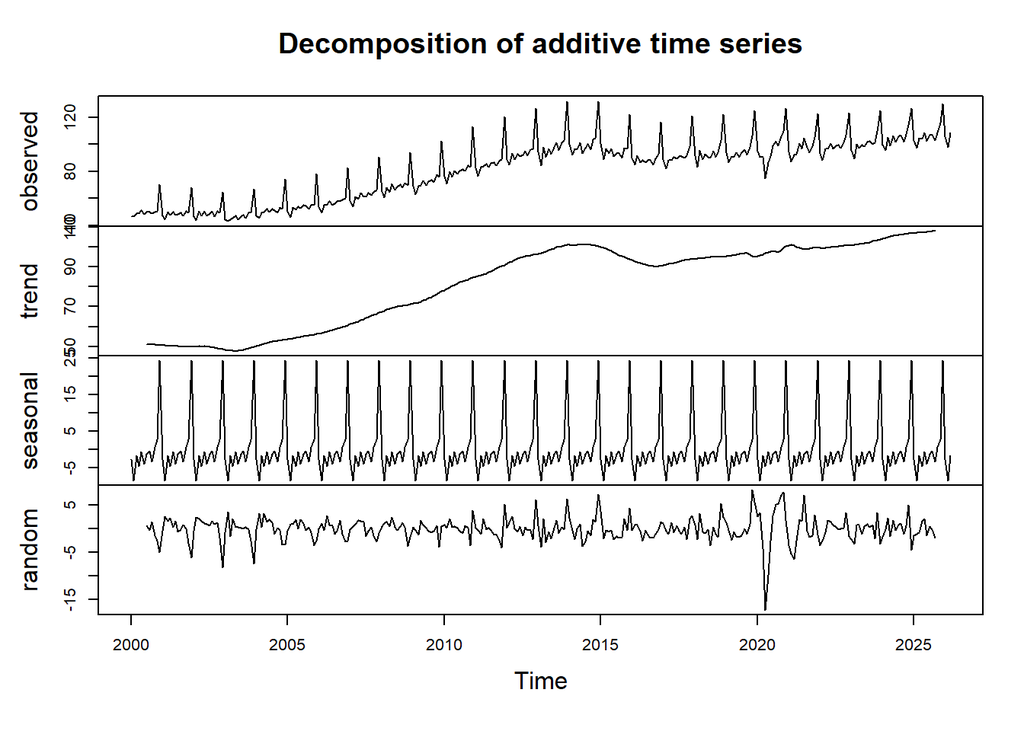

```r
par(mfrow = c(1, 2))
plot(decomp_pmc_add)
```

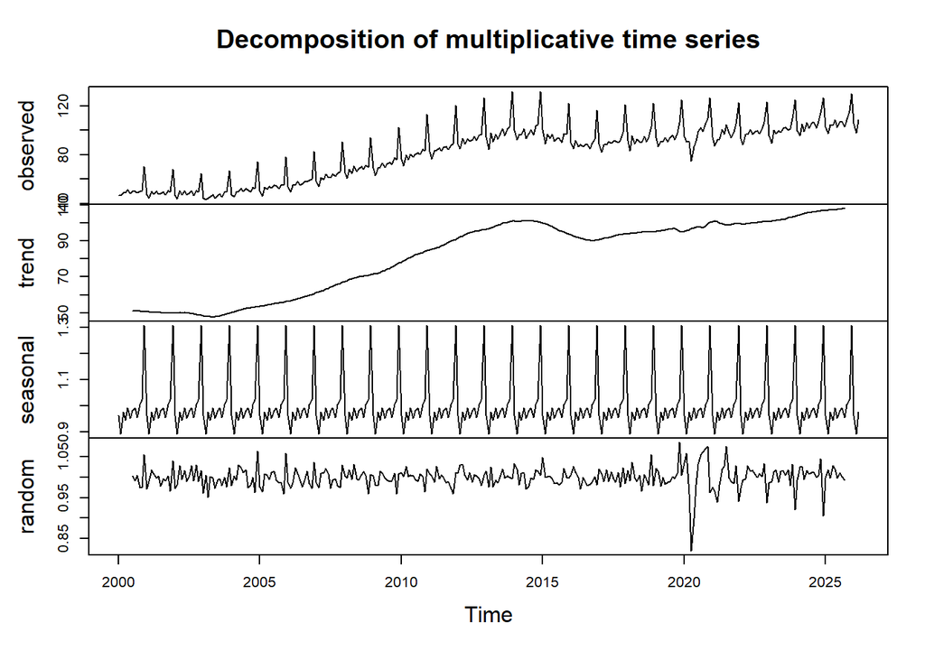

```r
plot(decomp_pmc_mult)
```

```r
par(mfrow = c(1, 1))
```

#### iii) Venda Semanal de One Piece

```r
# Identificando os "picos de lançamento" (semanas em que um novo volume estreia)
op_vals <- as.numeric(op_ts)
prev    <- c(0, op_vals[-length(op_vals)])
picos   <- which(op_vals > 5 * prev & op_vals > 50000)

intervalo_semanas <- diff(picos)
cat("Intervalo entre lançamentos (em semanas) - resumo:\n")
```

```
## Intervalo entre lançamentos (em semanas) - resumo:
```

```r
print(summary(intervalo_semanas))
```

```
##    Min. 1st Qu.  Median    Mean 3rd Qu.    Max.
##    1.00   13.00   13.00   13.49   17.00   24.00
```

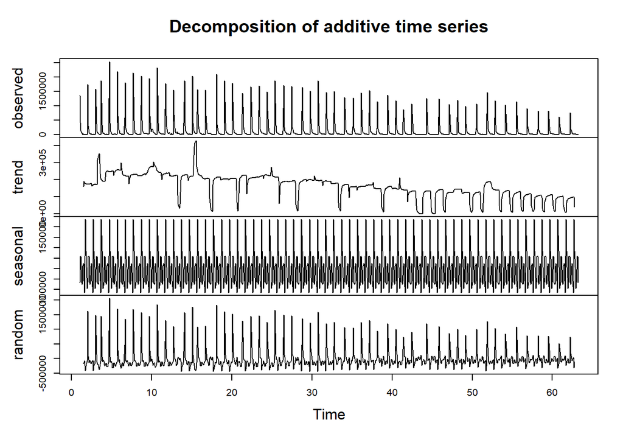

```r
decomp_op_add  <- decompose(op_ts, type = "additive")
decomp_op_mult <- decompose(op_ts, type = "multiplicative")

par(mfrow = c(1, 2))
plot(decomp_op_add)
```

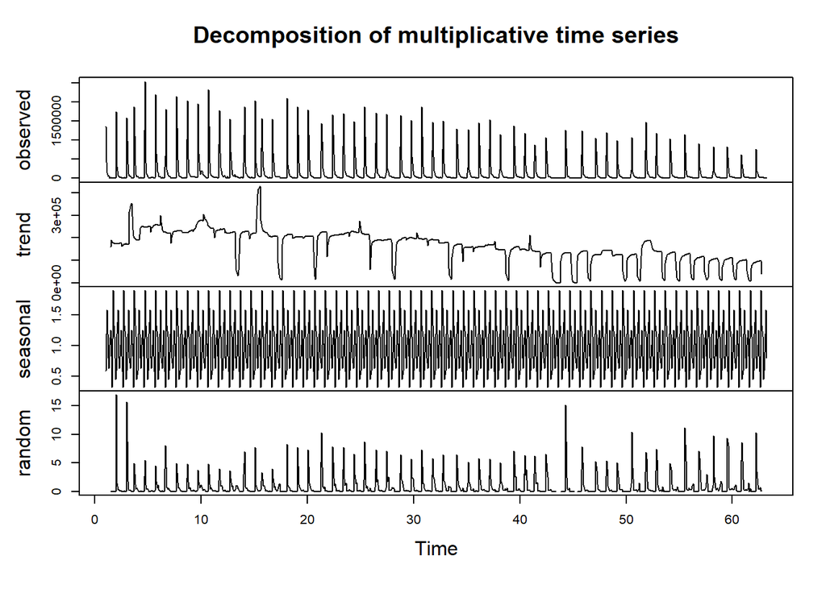

```r
plot(decomp_op_mult)
```

```r
par(mfrow = c(1, 1))
```

**Interpretação (One Piece):** Esta série não tem sazonalidade no sentido tradicional (calendário anual). O “ciclo” observado decorre do calendário de lançamento dos volumes no Japão, que se repete a cada **~13 semanas** (mediana, variando de 1 a 24 semanas) — aproximadamente trimestral. Por isso usamos `frequency = 13` ao construir o objeto `ts`, em vez do padrão `frequency = 52` que seria adequado a uma sazonalidade anual (e que, aqui, não capturaria o padrão real de lançamentos). Mesmo com o pico de vendas no lançamento caindo de mais de 2 milhões de exemplares (auge por volta de 2012) para algumas centenas de milhares nos anos recentes — refletindo a queda natural de interesse em uma obra que já está há muito tempo em publicação —, o formato relativo da curva de decaimento pós-lançamento (a fração das vendas do lançamento que permanece na 2ª, 3ª, 4ª semana) se mantém parecido entre ciclos antigos e recentes. Isso é evidência de sazonalidade **multiplicativa**: o “formato” do ciclo é proporcional ao nível de cada pico, e não uma quantidade fixa de exemplares. Vale ressaltar, porém, que como os intervalos entre lançamentos variam bastante (1 a 24 semanas, não exatamente 13 sempre), a decomposição clássica com `frequency` fixo é apenas uma aproximação razoável para esta série — uma limitação inerente ao método quando o ciclo real não é perfeitamente regular, diferente do que ocorre com as séries de CO2 e PMC, ambas estritamente atadas ao calendário.

### b) Previsão para 12 Meses – Série Escolhida: PMC

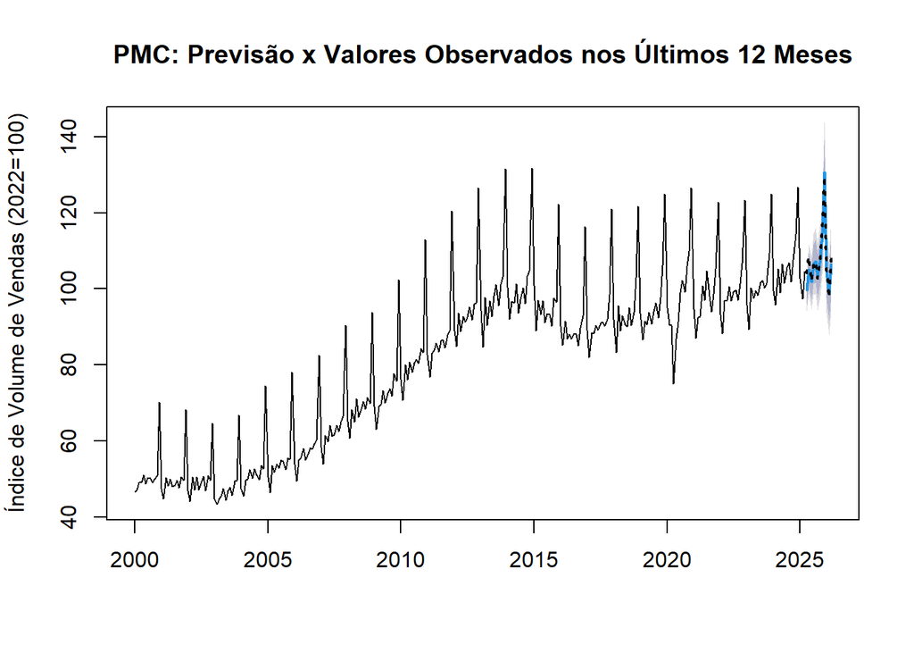

```r
# Separando os últimos 12 meses para validação
treino_pmc    <- window(pmc_ts, end = c(2025, 3))
validacao_pmc <- window(pmc_ts, start = c(2025, 4))

# Holt-Winters multiplicativo, horizonte de 12 meses
fit_pmc <- hw(treino_pmc, h = 12, seasonal = "multiplicative")

plot(fit_pmc, main = "PMC: Previsão x Valores Observados nos Últimos 12 Meses",
     ylab = "Índice de Volume de Vendas (2022=100)")
lines(validacao_pmc, lty = 3, lwd = 2)
```

```r
cat("\n--- Constantes de amortecimento estimadas (alpha, beta, gamma) ---\n")
```

```
##
## --- Constantes de amortecimento estimadas (alpha, beta, gamma) ---
```

```r
print(fit_pmc$model$par[c("alpha", "beta", "gamma")])
```

```
##        alpha         beta        gamma
## 0.5491889158 0.0001017355 0.3723199962
```

```r
cat("\n--- Medidas de acurácia no período de validação ---\n")
```

```
##
## --- Medidas de acurácia no período de validação ---
```

```r
# Ordem canônica do pacote forecast: accuracy(objeto_previsao, valores_reais)
accuracy(fit_pmc, validacao_pmc)
```

```
##                       ME     RMSE      MAE         MPE     MAPE      MASE
## Training set -0.01056224 2.323987 1.647649 -0.01789702 2.013897 0.4149760
## Test set      0.92122850 1.883109 1.360158  0.86277917 1.262727 0.3425686
##                    ACF1 Theil's U
## Training set 0.06179532        NA
## Test set     0.24088930 0.1536224
```

**Interpretação (Previsão):** O gráfico mostra que as previsões acompanham razoavelmente bem o padrão sazonal observado nos últimos 12 meses (inclusive o salto de dezembro), com os valores reais (linha pontilhada) permanecendo dentro ou próximos do intervalo de confiança de 95% do modelo ao longo do horizonte. A tabela de `accuracy` reporta, na linha “Test set”, as medidas de erro (RMSE, MAE, MAPE etc.) no período de validação — quanto menor o MAPE, melhor o ajuste relativo do modelo às variações mês a mês do índice.